# Analysis, visualization and interpretation of RNA-seq data

Michal Pawlak

12/10/2018

## Goal of this tutorial

Our goal in this tutorial is to bring a summary of the RNA-seq experiment into R/Bioconductor for visualization and statistical testing. We want to visualize the relationships between the samples (within and across conditions), and then we want to perform statistical tests to find which genes are changing their expression. Finally, we want to perform a functional analysis of differentially expressed genes (DEG) between selected conditions.

## Before starting

RNA-seq data analysis can be relatively easy and straightforward once you get familiar with basics of R programming. Before starting you should be able to run R or R-Studio (can work both on Linux/Mac and Windows), set work directory, create projects, load files/objects and be able to manupulate vectors, data frames, lists etc. Useful courses/tutorials can be found on-line e.g. (https://www.datacamp.com/courses/free-introduction-to-r), (https://www.coursera.org/learn/r-programming). Most of them it free of charge on the very basic level and paid subscription is required for further parts of the course.

Very useful R packages to play around with the data are `dplyr` (https://cran.r-project.org/web/packages/dplyr/vignettes/dplyr.html), `tidyr` (https://tidyr.tidyverse.org/) or `reshape2` (http://seananderson.ca/2013/10/19/reshape/). They allow to easly manipulate data frames, filter them, subset and change the format.

We will analyse data obtained from RNA-seq experiment performed from developing zebrafish hearts isolated at 30, 48 and 72 hpf published by Burkhard and Bakkers in 2018, in eLife (https://www.ncbi.nlm.nih.gov/pmc/articles/PMC5815850/).

## Install R studio

**Check R version** Make sure you have installed R version >= 3.4.0. by typing in your terminal `R` and once you check `q()` to quit R. If your version is not updated run `sudo apt install r-base`.

**Install R studio** Check Linux version by typing in terminal `uname -mrs`. Follow the [instructions](https://www.rstudio.com/products/rstudio/download-server/).

## Generating gene count matrices

Count-based statistical methods such as **DESeq2** (http://bioconductor.org/packages/DESeq2) (Love, Huber, and Anders 2014), **edgeR** (http://bioconductor.org/packages/edgeR) (M. D. Robinson, McCarthy, and Smyth 2009), **limma** (http://bioconductor.org/packages/limma) with the **voom** method (Law et al. 2014), **DSS** (http://bioconductor.org/packages/DSS) (H. Wu, Wang, and Wu 2013), **EBSeq** (http://bioconductor.org/packages/EBSeq) (Leng et al. 2013), **BaySeq** (http://bioconductor.org/packages/BaySeq) (Hardcastle and Kelly 2010) and **DEXSeq** (http://bioconductor.org/packages/DEXSeq) (Anders, Reyes, and Huber 2012) expect input data as obtained, e.g., from RNA-seq or another high-throughput sequencing experiment in the form of a matrix of integer values, or “counts”.

The value in the i-th row and the j-th column of the matrix tells how many reads (or fragments, for paired-end RNA-seq) have been assigned to feature i in sample j. For RNA-seq, a feature is typically a gene, a transcript or an exon. Analogously, for other types of assays, the rows of the matrix might correspond e.g., to binding regions (with ChIP-Seq), species of bacteria (with metagenomic datasets), or peptide sequences (with quantitative mass spectrometry).

The fact that the values in the matrix are counts of sequencing reads (in the case of single-end sequencing) or fragments (for paired-end sequencing) is important for the count-based statistical models, e.g. DESeq2 or edgeR , as only the counts allow assessing the measurement precision correctly.

**It is important to NEVER provide counts that have been normalized for sequencing depth/library size to these packages, as the statistical model is most powerful when applied to counts, and is designed to account for library size differences internally.**

In the sections below, we will show to to generate gene-level count matrices in R from the **Salmon** (http://salmon.readthedocs.io/en/latest/index.html) output of quasi-mappings of reads to transcript/gene positions that are computed without performing a base-to-base alignment of the read to the transcript/gene. Quasi-mapping is typically much faster to compute than traditional (or full) alignments, and can sometimes provide superior accuracy by being more robust to errors in the read or genomic variation from the reference sequence (https://academic.oup.com/bioinformatics/article/32/12/i192/2288985).

## Transcript abundance files and tximport input

A newer and recommended pipeline is to use fast transcript abundance quantifiers upstream of DESeq2, and then to create gene-level count matrices for use with DESeq2 by importing the quantification data using the `tximport` package.

We will create a data frame containing directories to `quant.sf` files and sample infromation. A separate `quant.sf` is generated by `Salmon` for each sample and contains 5 columns: Name, Length, EffectiveLength, TPM, NumReads. We are particularly interested in `Name` column containing transcript IDs and `NumReads` containing unnormalized transcirpt counts.

```r
library("tximport")

# creating a list of quant.sf file directories modify
# depending on your quant.sf directories
files <- list.files("./quants/", pattern = "genes.sf", full.names = TRUE,
    recursive = TRUE)
# inspecting files
files
```

```
## [1] "./quants//A30_quant/quant.genes.sf"
## [2] "./quants//A48_quant/quant.genes.sf"
## [3] "./quants//A72_quant/quant.genes.sf"
## [4] "./quants//B30_quant/quant.genes.sf"
## [5] "./quants//B48_quant/quant.genes.sf"
## [6] "./quants//B72_quant/quant.genes.sf"
## [7] "./quants//C30_quant/quant.genes.sf"
## [8] "./quants//C48_quant/quant.genes.sf"
## [9] "./quants//C72_quant/quant.genes.sf"
```

```r
# creating a data frame containing samples information
sampleTable <- data.frame(replicate = c("1", "1", "1", "2", "2",
    "2", "3", "3", "3"), time = c("30hpf", "48hpf", "72hpf",
    "30hpf", "48hpf", "72hpf", "30hpf", "48hpf", "72hpf"))
rownames(sampleTable) <- paste(sampleTable$time, sampleTable$replicate,
    sep = "_")
sampleTable$time_replicate = paste(sampleTable$time, sampleTable$replicate,
    sep = "_")

# assigning column names for each sample
names(files) <- paste0(sampleTable$time_replicate)

# inspecting sampleTable
sampleTable
```

```
##         replicate  time time_replicate
## 30hpf_1         1 30hpf        30hpf_1
## 48hpf_1         1 48hpf        48hpf_1
## 72hpf_1         1 72hpf        72hpf_1
## 30hpf_2         2 30hpf        30hpf_2
## 48hpf_2         2 48hpf        48hpf_2
## 72hpf_2         2 72hpf        72hpf_2
## 30hpf_3         3 30hpf        30hpf_3
## 48hpf_3         3 48hpf        48hpf_3
## 72hpf_3         3 72hpf        72hpf_3
```

```r
# this function will output gene-level matrices. We can avoid
# gene-level summarization by setting txOut=TRUE
txi <- tximport(files, type = "salmon", txOut = TRUE)
```

## Creating DESeq2 object

Finally, we can construct a `DESeqDataSet` from the txi object and sample information in samples. The object class used by the `DESeq2` package to store the read counts and the intermediate estimated quantities during statistical analysis is the `DESeqDataSet`, which will usually be represented in the code here as an object `dds`.

```r
library("DESeq2")
dds <- DESeqDataSetFromTximport(txi, colData = sampleTable, design = ~time)
# by removing rows in which there are very few reads, we
# reduce the memory size of the dds data object, and we
# increase the speed of the transformation and testing
# functions within DESeq2
keep <- rowSums(counts(dds)) >= 10
dds <- dds[keep, ]
```

## Performing counts normalization

‘Regularized log’ transformation the count data to the log2 scale in a way which minimizes differences between samples for rows with small counts, and which normalizes with respect to **library size**. The rlog transformation produces a similar variance stabilizing effect as `varianceStabilizingTransformation`, though rlog is more robust in the case *when the size factors vary widely*. The transformation is useful when checking for outliers or as input for machine learning techniques such as clustering or linear discriminant analysis. rlog takes as input a `DESeqDataSet` and returns a `RangedSummarizedExperiment` object.

```r
# blind=FALSE should be used for transforming data for
# downstream analysis, where the full use of the design
# information should be made.
dds <- estimateSizeFactors(dds)
dds <- estimateDispersions(dds)
rld <- rlog(dds, blind = FALSE)
head(assay(rld), 3)
```

```
##                     30hpf_1  48hpf_1  72hpf_1  30hpf_2  48hpf_2  72hpf_2
## ENSDARG00000112256 1.130676 1.638539 1.123486 1.138663 2.254659 1.378633
## ENSDARG00000110727 2.521965 2.470886 2.825570 2.593352 3.143386 1.857601
## ENSDARG00000112708 4.298015 3.918395 4.233051 3.678196 3.878354 3.936926
##                     30hpf_3  48hpf_3  72hpf_3
## ENSDARG00000112256 1.207858 1.549916 1.038863
## ENSDARG00000110727 2.006745 2.565326 2.203861
## ENSDARG00000112708 3.808507 3.708980 3.957403
```

```r
saveRDS(rld, file = "rld.cardio.RDS")
rld = readRDS("rld.cardio.RDS")
```

#### Validating the effect of normalizationa and quality assessment (QA)

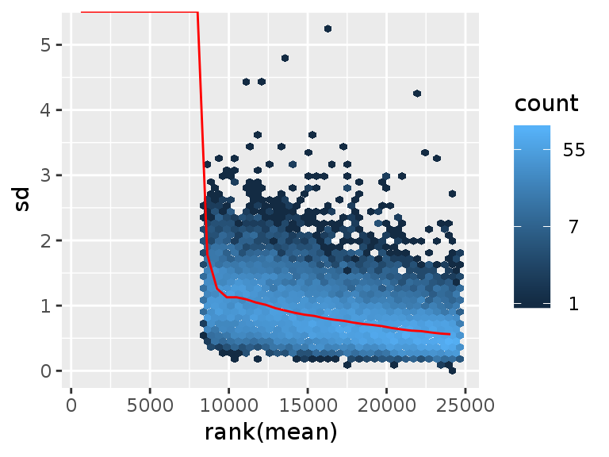

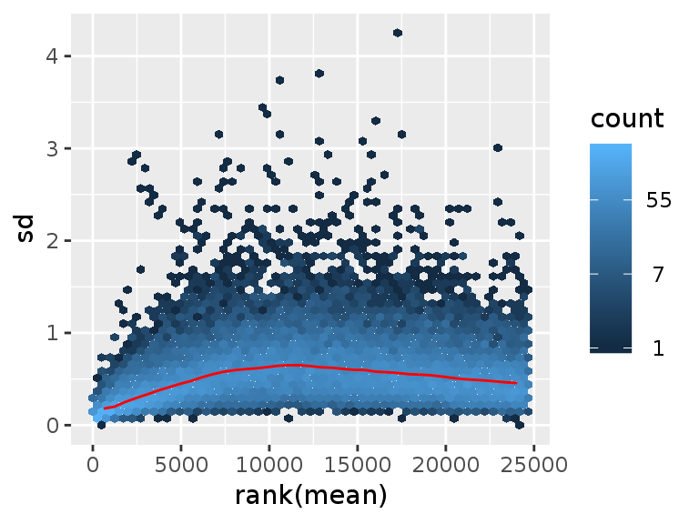

```r
# load this package to visualize
library("vsn")
# before
meanSdPlot(log2(counts(dds, normalized = TRUE)))
# and after transformation
meanSdPlot(assay(rld))
```

**Heatmap of the sample-to-sample distances and pairwise Pearson correlation**

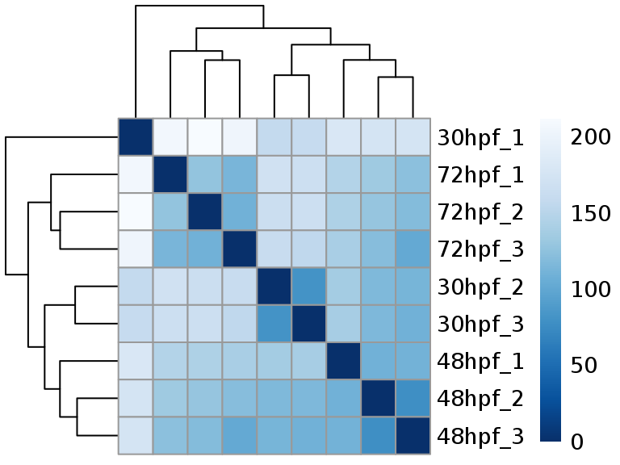

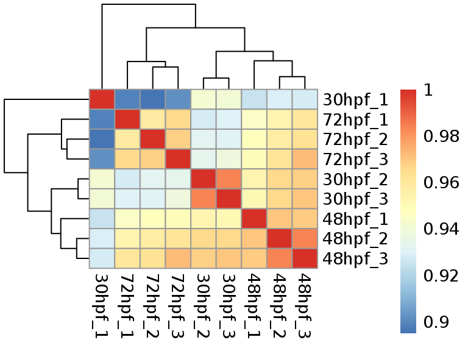

```r
library("pheatmap")
library("RColorBrewer")
sampleDists <- dist(t(assay(rld)))
sampleDistMatrix <- as.matrix(sampleDists)
colors <- colorRampPalette(rev(brewer.pal(9, "Blues")))(255)
pheatmap(sampleDistMatrix, clustering_distance_rows = sampleDists,
    clustering_distance_cols = sampleDists, col = colors, show_colnames = FALSE)
rld_cor <- cor(assay(rld), method = "pearson")
pheatmap(rld_cor)
```

**PCA analysis**

Related to the distance matrix is the PCA plot, which shows the samples in the 2D plane spanned by their first two principal components. This type of plot is useful for visualizing the overall effect of experimental covariates and batch effects.

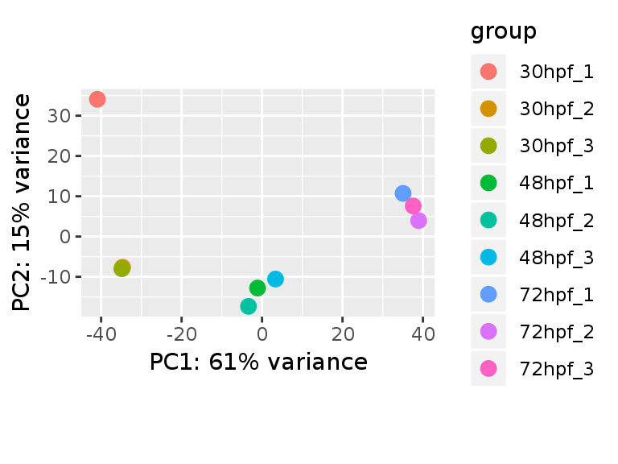

```r
plotPCA(rld, intgroup = c("time_replicate"))
```

**Heatmaps, clustering, single-gene visualization**

We can have a look at selected genes across all conditions to validate how reproducible are the replicates

```r
# this packages will draw the heatmap
library("pheatmap")
# select 20 genes with the highest mean across all samples
select <- order(rowMeans(assay(rld)), decreasing = TRUE)[1:20]
# draw the heatmap
rld_table <- as.data.frame(assay(rld)[, c(1, 4, 7, 2, 5, 8, 3,
    6, 9)])
rld_table[select, ]
```

```
##                     30hpf_1  30hpf_2  30hpf_3  48hpf_1  48hpf_2  48hpf_3
## ENSDARG00000096403 22.83947 20.62734 20.28586 22.10687 20.65143 19.73168
## ENSDARG00000080337 20.13976 20.42813 20.46524 21.03155 20.77904 21.05205
## ENSDARG00000082753 19.79728 19.15459 19.29618 20.24644 19.65834 19.65815
## ENSDARG00000089382 21.61365 19.07142 18.81330 20.69630 19.20607 18.37729
## ENSDARG00000110315 21.07523 18.83146 18.85387 20.12051 18.89111 18.09035
## ENSDARG00000116179 20.48084 17.10412 17.09908 17.65645 17.66195 16.99950
## ENSDARG00000098155 19.70749 16.91357 16.74130 18.24297 17.06652 16.12170
## ENSDARG00000111458 19.17568 16.99216 16.68140 18.15310 17.02256 16.26764
## ENSDARG00000116076 20.50832 16.43346 16.07504 18.38889 16.73746 15.80363
## ENSDARG00000115978 19.67938 16.76108 16.50703 18.48757 16.47258 15.39879
## ENSDARG00000114910 20.04827 15.95165 15.76820 17.75215 16.35563 15.49938
## ENSDARG00000117174 17.88129 15.77198 15.99631 18.11207 15.85900 14.58581
## ENSDARG00000020850 16.63168 16.38484 15.98526 15.99283 15.85903 15.87004
## ENSDARG00000099970 16.86045 15.33665 15.60833 16.30139 15.97790 15.71254
## ENSDARG00000113671 17.77336 15.37620 15.36729 16.57025 15.42771 14.54908
## ENSDARG00000063905 14.57181 15.32903 15.61791 16.01191 15.59490 16.00544
## ENSDARG00000115988 17.97256 15.37486 15.55379 16.80138 15.14892 14.11259
## ENSDARG00000103635 17.61143 15.34632 15.34497 16.68546 15.18299 14.25107
## ENSDARG00000105341 14.55673 13.48917 14.07559 16.01702 15.47858 15.39808
## ENSDARG00000028213 15.15981 14.23754 15.49427 14.74398 15.30451 15.79287
##                     72hpf_1  72hpf_2  72hpf_3
## ENSDARG00000096403 22.06765 21.51171 20.30709
## ENSDARG00000080337 21.03918 21.59215 21.24150
## ENSDARG00000082753 20.23453 20.64653 19.99562
## ENSDARG00000089382 20.61292 20.25257 18.91881
## ENSDARG00000110315 19.97167 19.47477 18.54249
## ENSDARG00000116179 16.18903 17.51185 17.77518
## ENSDARG00000098155 18.24804 17.80031 16.81733
## ENSDARG00000111458 18.43199 17.99507 16.84129
## ENSDARG00000116076 18.31286 17.90544 16.40383
## ENSDARG00000115978 18.04912 17.81247 15.69055
## ENSDARG00000114910 17.51042 17.16150 16.14347
## ENSDARG00000117174 18.25310 17.49081 15.16682
## ENSDARG00000020850 15.98288 16.06309 15.86921
## ENSDARG00000099970 16.06025 15.90039 15.98853
## ENSDARG00000113671 16.48523 15.90487 14.98924
## ENSDARG00000063905 16.03474 16.76168 16.33015
## ENSDARG00000115988 16.41728 16.02612 14.15617
## ENSDARG00000103635 16.41712 15.94968 14.53146
## ENSDARG00000105341 16.14847 15.82005 15.63243
## ENSDARG00000028213 15.26657 14.45028 15.62491
```

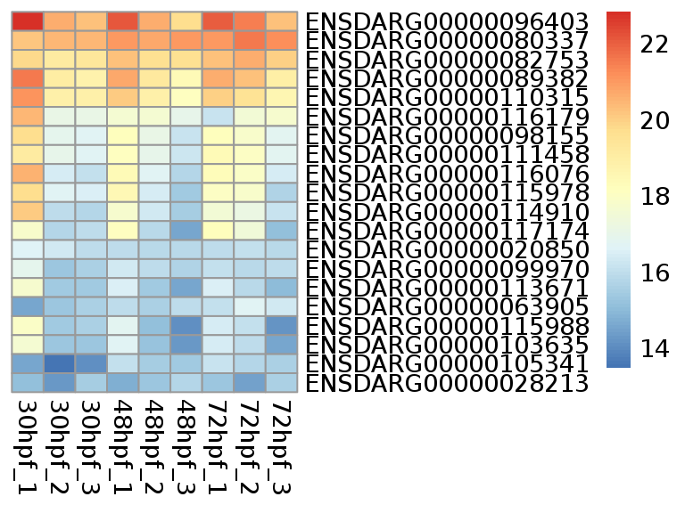

```r
pheatmap(rld_table[select, ], cluster_rows = FALSE, show_rownames = TRUE,
    cluster_cols = FALSE)
```

We can do the same visualization but replace ENSEMBL annotation with other annotation

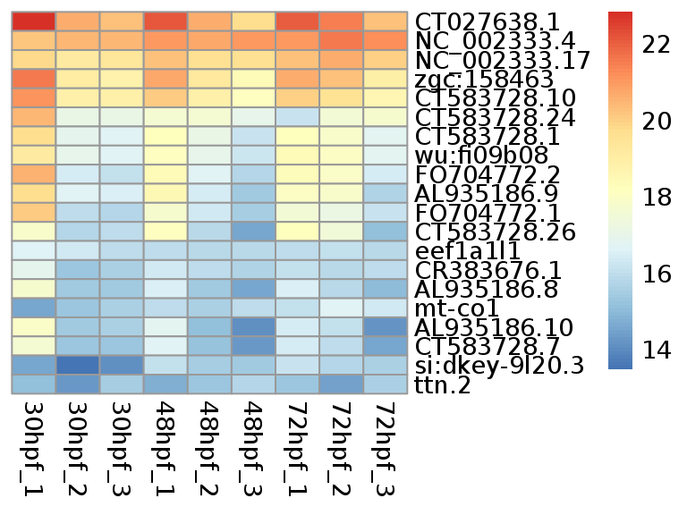

```r
# use biomaRt to convert ensmbl ids into e.g. gene name or
# NCBI gene ids often biomaRt packages can be corrupted so
# the way around is to install developmental version
BiocInstaller::biocLite("grimbough/biomaRt")
library(biomaRt)
# select a dataset and save as mart object
ensembl = useMart("ensembl")
mart <- biomaRt::useDataset("drerio_gene_ensembl", mart = ensembl)

# create a column from rownames
rld_table$ensembl <- rownames(rld_table)

# create a datafame with alternative annotations
biomaRt_list_rld <- getBM(filters = "ensembl_gene_id", attributes = c("ensembl_gene_id",
    "external_gene_name", "entrezgene"), values = rld_table$ensembl,
    mart = mart, bmHeader = TRUE, uniqueRows = TRUE)

# same heatmap as above but with gene name ids
rld_table_alt = dplyr::inner_join(biomaRt_list_rld, rld_table,
    by = c(`Gene stable ID` = "ensembl"))
select <- order(rowMeans(rld_table_alt[, c(4:12)]), decreasing = TRUE)[1:20]
pheatmap(rld_table_alt[select, c(4:12)], cluster_rows = FALSE,
    cluster_cols = FALSE, labels_row = rld_table_alt[select,
        2])
```

## Differential expression analysis

We can also visualize selected contrasts by MA plot which shows log2 FC vs. mean normalized counts. Dots in red represent values with padj < 0.05.

**Performing differential expression analysis**

```r
# DEG
dds <- DESeq(dds, quiet = F)
saveRDS(dds, file = "dds.cardio.RDS")
Res <- results(dds)
Res
```

```
## log2 fold change (MLE): time 72hpf vs 30hpf
## Wald test p-value: time 72hpf vs 30hpf
## DataFrame with 24668 rows and 6 columns
##                        baseMean log2FoldChange     lfcSE       stat
##                       <numeric>      <numeric> <numeric>  <numeric>
## ENSDARG00000112256 3.352197e+00      0.3115908 1.9188394  0.1623850
## ENSDARG00000110727 6.590425e+00     -0.2098328 1.3989198 -0.1499963
## ENSDARG00000112708 1.591153e+01      0.2342126 0.6803387  0.3442588
## ENSDARG00000111213 9.334526e-01      1.5744767 3.3762412  0.4663401
## ENSDARG00000114192 2.497331e+04     -0.6536351 0.7810246 -0.8368944
## ...                         ...            ...       ...        ...
## ENSDARG00000059680   468.228671     -1.6068197 0.2990204 -5.3736121
## ENSDARG00000110164     1.450917      0.5372385 2.2554517  0.2381955
## ENSDARG00000079547    11.967389      2.4596113 1.1008075  2.2343699
## ENSDARG00000002750   212.065346     -0.9083253 0.3810754 -2.3835843
## ENSDARG00000053130    15.970996      2.8925505 0.9595686  3.0144280
##                          pvalue         padj
##                       <numeric>    <numeric>
## ENSDARG00000112256    0.8710026    0.9413078
## ENSDARG00000110727    0.8807675    0.9454294
## ENSDARG00000112708    0.7306517    0.8641719
## ENSDARG00000111213    0.6409721           NA
## ENSDARG00000114192    0.4026519    0.6289510
## ...                         ...          ...
## ENSDARG00000059680 7.717480e-08 2.469376e-06
## ENSDARG00000110164 8.117294e-01           NA
## ENSDARG00000079547 2.545874e-02 9.945549e-02
## ENSDARG00000002750 1.714496e-02 7.431023e-02
## ENSDARG00000053130 2.574643e-03 1.704441e-02
```

```r
# contrast for 30 vs 48 hpf
Res_30_48 = results(dds, contrast = c("time", "30hpf", "48hpf"),
    independentFiltering = T)
# summary of 30 vs 48 hpf comparison
summary(Res_30_48)
```

```
##
## out of 24668 with nonzero total read count
## adjusted p-value < 0.1
## LFC > 0 (up)     : 1255, 5.1%
## LFC < 0 (down)   : 1337, 5.4%
## outliers [1]     : 101, 0.41%
## low counts [2]   : 3348, 14%
## (mean count < 4)
## [1] see 'cooksCutoff' argument of ?results
## [2] see 'independentFiltering' argument of ?results
```

```r
# how many DEG with padj<0.05
sum(Res_30_48$padj < 0.05, na.rm = TRUE)
```

```
## [1] 1821
```

```r
plotMA(Res_30_48, ylim = c(-10, 10), alpha = 0.05, main = "DEG 30 vs 48 hpf")

# same for 48 vs 72 hpf
Res_48_72 = results(dds, contrast = c("time", "48hpf", "72hpf"),
    independentFiltering = T)
Res_48_72
```

```
## log2 fold change (MLE): time 48hpf vs 72hpf
## Wald test p-value: time 48hpf vs 72hpf
## DataFrame with 24668 rows and 6 columns
##                        baseMean log2FoldChange     lfcSE       stat
##                       <numeric>      <numeric> <numeric>  <numeric>
## ENSDARG00000112256 3.352197e+00      3.0866041 1.7387993  1.7751353
## ENSDARG00000110727 6.590425e+00      1.3170785 1.3538731  0.9728228
## ENSDARG00000112708 1.591153e+01     -0.4161780 0.6723181 -0.6190195
## ENSDARG00000111213 9.334526e-01      0.5933531 3.2500046  0.1825699
## ENSDARG00000114192 2.497331e+04     -0.3487468 0.7810310 -0.4465211
## ...                         ...            ...       ...        ...
## ENSDARG00000059680   468.228671      1.0831098 0.2989077   3.623559
## ENSDARG00000110164     1.450917     -0.3746291 2.2171862  -0.168966
## ENSDARG00000079547    11.967389     -1.9466646 1.0540166  -1.846901
## ENSDARG00000002750   212.065346      1.1545825 0.3786896   3.048889
## ENSDARG00000053130    15.970996     -2.0852708 0.9088785  -2.294334
##                          pvalue       padj
##                       <numeric>  <numeric>
## ENSDARG00000112256   0.07587555         NA
## ENSDARG00000110727   0.33064140  0.7899800
## ENSDARG00000112708   0.53590348  0.8896229
## ENSDARG00000111213   0.85513547         NA
## ENSDARG00000114192   0.65522087  0.9336261
## ...                         ...        ...
## ENSDARG00000059680 0.0002905765 0.01341352
## ENSDARG00000110164 0.8658233625         NA
## ENSDARG00000079547 0.0647614463 0.41179501
## ENSDARG00000002750 0.0022968940 0.05944643
## ENSDARG00000053130 0.0217713306 0.23450167
```

```r
sum(Res_48_72$padj < 0.05, na.rm = TRUE)
```

```
## [1] 727
```

[figure not shown]

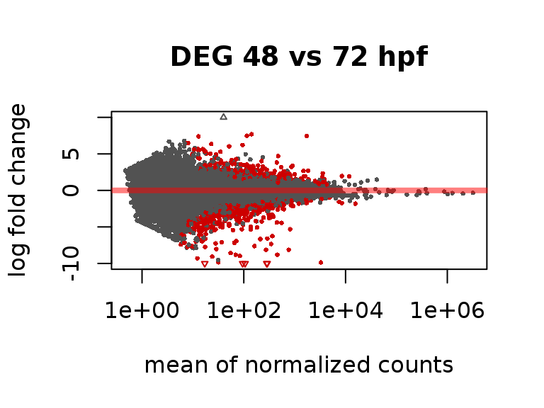

```r
plotMA(Res_48_72, ylim = c(-10, 10), alpha = 0.05, main = "DEG 48 vs 72 hpf")
```

**Saving and exporting DEG table**

Often creating a table with different conditions and DEG can be useful to perform further analysis and visualisations. We can also save a data frame as csv/tsv file or excel (xlsx) file. A number of packages can simply our work especially in terms of data table manipulation and filtering (`dplyr`, `tibble`) and exporting data (`xlsx`). We can also convert ENSEMBL gene IDs to any other annotations available in biomaRt database. For that purpose we will use `biomaRt` package.

```r
library("xlsx")
library("dplyr")

# create data frame with log2FC, pvalue and padj for DEG 30
# vs 48 hpf
DEG_30_48 = as.data.frame(Res_30_48) %>% tibble::rownames_to_column("ENSEMBL") %>%
    dplyr::select(ENSEMBL, log2FoldChange, pvalue, padj)
# create data frame with log2FC, pvalue and padj for DEG 48
# vs 72 hpf
DEG_48_72 = as.data.frame(Res_48_72) %>% tibble::rownames_to_column("ENSEMBL") %>%
    dplyr::select(ENSEMBL, log2FoldChange, pvalue, padj)

# combine both data frames in one
DEG = dplyr::inner_join(DEG_30_48, DEG_48_72, by = "ENSEMBL")
names(DEG) = c("Gene stable ID", "log2FC_30vs48", "pval_30vs48",
    "padj_30vs48", "log2FC_48vs72", "pval_48vs72", "padj_48vs72")
DEG_cutoff = dplyr::filter(DEG, padj_30vs48 <= 0.05 | padj_48vs72 <=
    0.05)


biomaRt_list_deg <- getBM(filters = "ensembl_gene_id", attributes = c("ensembl_gene_id",
    "external_gene_name", "entrezgene"), values = DEG_cutoff$`Gene stable ID`,
    mart = mart, bmHeader = TRUE, uniqueRows = TRUE)
# merging novel gene names with DEG table
DEG_annot = dplyr::inner_join(biomaRt_list_deg, DEG_cutoff, by = "Gene stable ID")
# saving data as csv
write.csv(DEG_annot, file = "DEG_cardio.csv")
# saving data as xlsx
write.xlsx(DEG_annot, row.names = F, showNA = T, file = "DEG_cardio.xlsx")
```

Another way to handle data is to perform a clustering i.e. k-mean or hierarchical. It allows to identify a group of genes that change in similar way in given conditions.

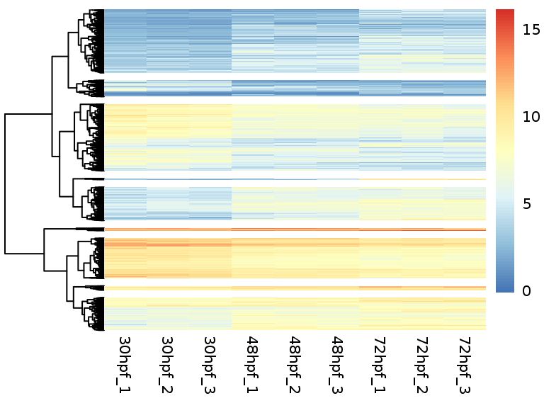

```r
# hierarchical clustering of DEG

rld_DE = semi_join(rld_table_alt, DEG_annot, by = "Gene stable ID")
clustering = pheatmap(rld_DE[, c(4:12)], cluster_rows = TRUE,
    cluster_cols = FALSE, show_rownames = FALSE, fontsize = 8,
    cutree_rows = 9)
```

We can plot genes from individual clusters to have a look at the pattern of expression for all of them or just single genes across conditions

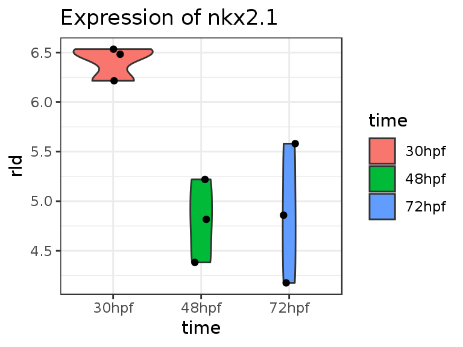

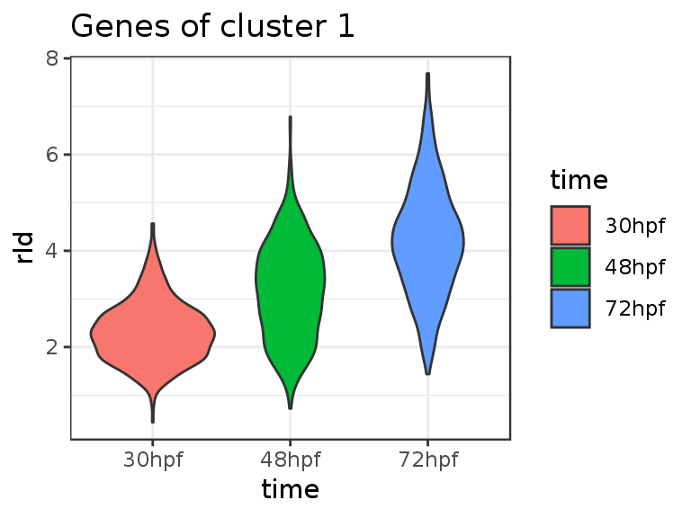

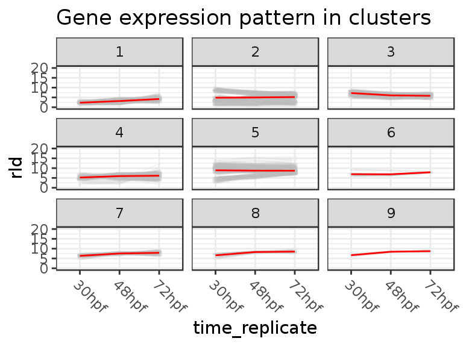

```r
library("reshape2")
library("ggplot2")

# order genes in rld_table_alt as in the heatmap
cluster_genes = rld_DE[clustering$tree_row[["order"]], ]
# add column with cluster numbers
cluster_genes$cluster = sort(cutree(clustering$tree_row, k = 9))

# we need to reshape data to make it easy to read and
# compatible e.g. with ggplot2

# we want to have a look at individual gene e.g. 'nkx2.1'
keycol <- "time_replicate"
valuecol <- "rld"
gathercols <- c(colnames(cluster_genes[4:12]))
cluster_genes_gene = cluster_genes %>% tidyr::gather_(keycol,
    valuecol, gathercols)
cluster_genes_gene = cluster_genes_gene %>% tidyr::separate("time_replicate",
    sep = "_", into = c("time", "replicate"))

ggplot(dplyr::filter(cluster_genes_gene, `Gene name` == "nkx2.1")) +
    geom_violin(aes(time, rld, fill = time)) + geom_jitter(aes(time,
    rld), height = 0, width = 0.1) + theme_bw() + labs(title = "Expression of nkx2.1")

# or we visualize all genes from cluster 1
ggplot(dplyr::filter(cluster_genes_gene, cluster == "1")) + geom_violin(aes(time,
    rld, fill = time)) + theme_bw() + labs(title = "Genes of cluster 1")


# get means for biological replicates
cluster_genes$`30hpf` = rowMeans(cluster_genes[, 4:6])
cluster_genes$`48hpf` = rowMeans(cluster_genes[, 7:9])
cluster_genes$`72hpf` = rowMeans(cluster_genes[, 10:12])

# create a data frame to plot individual genes in the
# clusters
keycol <- "time_replicate"
valuecol <- "rld"
gathercols <- c(colnames(cluster_genes[14:16]))
cluster_genes_long = cluster_genes %>% tidyr::gather_(keycol,
    valuecol, gathercols)

# plot clusters
pcp_cl <- ggplot(cluster_genes_long, aes(time_replicate, rld,
    group = `Gene stable ID`, colour = cluster))
jit <- position_jitter(width = 0.08, height = 0.08)

pcp_cl + geom_line(position = jit, colour = alpha("grey", 1/10)) +
    theme_bw() + stat_summary(aes(group = cluster), fun.y = mean,
    geom = "line", colour = "red") + facet_wrap(~cluster) + theme(axis.text.x = element_text(angle = -45,
    hjust = 0)) + scale_y_continuous(limits = c(0, 20)) + labs(title = "Gene expression pattern in clusters")
```

**Functional Analyis: GO and KEGG analysis**

We can perform gene ontology (GO) analysis or KEGG pathway analysis by using a number of available R packages. We can also export data stored e.g. as csv and perform on-line available tools such as DAVID or Panther. In this example we will create a list of differentially expressed genes both down- and up-regulated between different conditions. `clusterProfiler` package offers an useful tool to perform GO term enrichment analysis, KEGG pathway analysis and more.

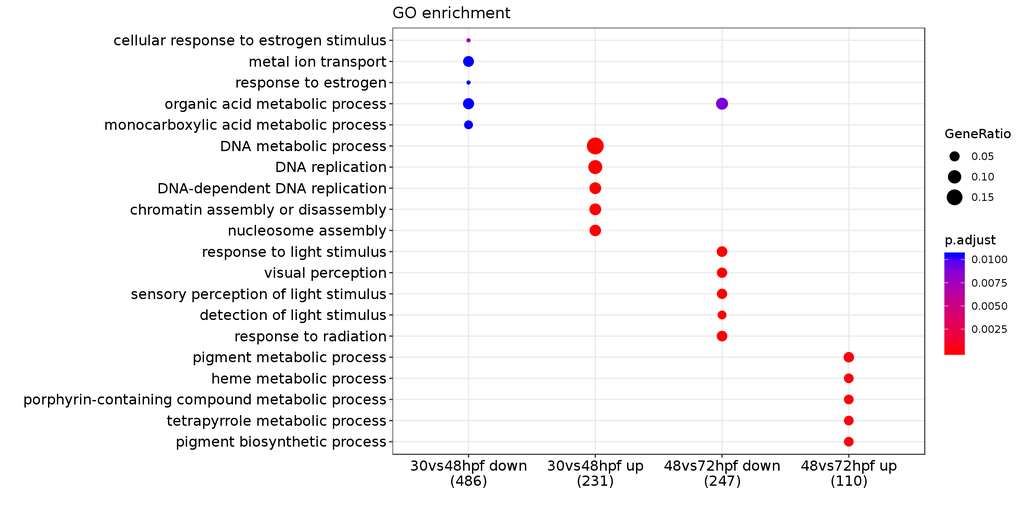

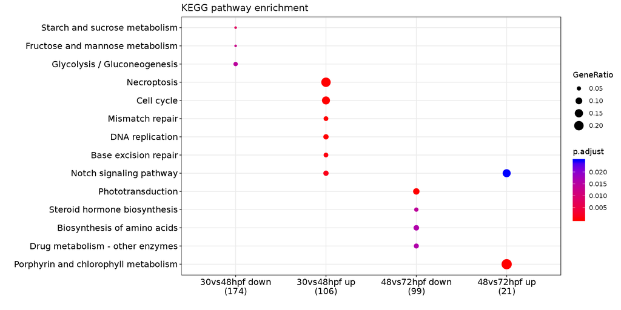

[figure not shown]

[figure not shown]

```r
library("clusterProfiler")
library("org.Dr.eg.db")

up3048 = dplyr::filter(DEG_annot, log2FC_30vs48 < -2)
down3048 = dplyr::filter(DEG_annot, log2FC_30vs48 > 2)

up4872 = dplyr::filter(DEG_annot, log2FC_48vs72 < -2)
down4872 = dplyr::filter(DEG_annot, log2FC_48vs72 > 2)


FA_list = list(`30vs48hpf down` = up3048$`NCBI gene ID`, `30vs48hpf up` = down3048$`NCBI gene ID`,
    `48vs72hpf down` = up4872$`NCBI gene ID`, `48vs72hpf up` = down4872$`NCBI gene ID`)

FA_list = lapply(FA_list, na.exclude)

enrichGO <- compareCluster(geneCluster = FA_list, fun = "enrichGO",
    OrgDb = org.Dr.eg.db, ont = "BP", pvalueCutoff = 0.05, pAdjustMethod = "BH")
enrichKEGG <- compareCluster(geneCluster = FA_list, fun = "enrichKEGG",
    organism = "dre", keyType = "kegg", pvalueCutoff = 0.05,
    universe, pAdjustMethod = "BH")

dotplot(enrichGO, showCategory = 5, by = "geneRatio", title = "GO enrichment")
dotplot(enrichKEGG, showCategory = 5, by = "geneRatio", title = "KEGG pathway enrichment")

# GO enrichment of genes in cluster 2

cluster_2 = as.vector(dplyr::filter(cluster_genes_gene, cluster ==
    "2")[, 1])
enrichGO_clust_2 = clusterProfiler::enrichGO(cluster_2, OrgDb = org.Dr.eg.db,
    ont = "BP", keyType = "ENSEMBL", pAdjustMethod = "BH", pvalueCutoff = 0.01)

barplot(enrichGO_clust_2, showCategory = 8)
dotplot(enrichGO_clust_2)
```